# Maintain your brain, Primary Cognitive Composite Variable

## cogmeanz_full

- Primary Cognitive Composite Variable
  - Cogstate Detection
  - Cogstate Identification
  - Cogstate One Back
  - Cambridge Brain Sciences Spatial (tokens) Search
  - Cambridge Brain Sciences Grammatical Reasoning
  - Cogstate One Card Learning
  - Cambridge Brain Sciences Paired Associates

These analyses use `bl_adritotal` (as named in the original SPSS file) as the ADRI baseline covariate.

These results exclude those participants who were eligible for fewer than 2 modules but who were randomised. This results in N=6104.

```r
# read in functions and data
source("functions.R")
myb_dat <- read.csv(paste0("../../Data/",params$data,".csv"))
```

Inference for differences in rc_trial_time trend by group_type_id for cogmeanz_full

## Data summary

```r
myb_dat %>%
  group_by(.dots = lapply(params$predictors, as.symbol)) %>%
  summarize_at(.vars = params$response, .funs = list(Mean = mean, Sd = sd, N_obs = ~length(.)), na.rm=T)
```

```
## # A tibble: 8 x 5
## # Groups:   rc_trial_time [4]
##   rc_trial_time group_type_id    Mean    Sd N_obs
##           <int>         <int>   <dbl> <dbl> <int>
## 1             1             1  0.0192 1.00   3053
## 2             1             2 -0.0192 0.996  3051
## 3            10             1  0.228  1.00   2281
## 4            10             2  0.389  1.02   1612
## 5            11             1  0.206  0.994  2014
## 6            11             2  0.406  1.02   1428
## 7            12             1  0.115  1.02   2046
## 8            12             2  0.319  1.06   1442
```

```r
# if want to run
if(!params$final){

  # run models
  fitted_mods <- MYB_fit(params$response, params$predictors,
                       params$covariates, params$id, myb_dat, times = plannedtimes)
  # save models
  save(fitted_mods,file = paste0("../../Results/baseline_sd/",params$response))

} else {
  load(file = paste0("../../Results/baseline_sd/",params$response))
}
```

```r
#plot models

if(!params$final){
  lapply(fitted_mods, plot, form = cond)
}
```

```r
#check summary is okay

if(!params$final){
  lapply(fitted_mods, summary)
}
```

## Results

```r
if(!params$final){

  # calculate CI
  res_tab = MYB_inf(fitted_mods, params$response)

  # save models
  write.csv(res_tab,file = paste0("../../Results/baseline_sd/",params$response,"_table.csv"), row.names = FALSE)



} else {
  res_tab <- read.csv(file = paste0("../../Results/baseline_sd/",params$response,"_table.csv"))


}

res <- res_tab %>%
  transmute(response,
            adjusted,
            base_3yr_did = round(planned,3),
            LCL = round(asymp.LCL,3),
            UCL = round(asymp.UCL,3),
            zstat,
            pz,
            Chisq,
            `p.value` = ifelse (`p.value` < 0.001, "<0.001",paste("= ",round(`p.value`,3)))
)

res
```

```
##        response adjusted base_3yr_did   LCL   UCL zstat     pz     Chisq
## 1 cogmeanz_full       No        0.181 0.134 0.228 7.573 <0.001 89.724(3)
## 2 cogmeanz_full      Yes        0.179 0.132 0.226 7.496 <0.001 89.198(3)
##   p.value
## 1  <0.001
## 2  <0.001
```

```r
evidence_unadj = ifelse(res_tab$p.value[1]<0.05, "evidence", "no evidence")
evidence_adj = ifelse(res_tab$p.value[2]<0.05, "evidence", "no evidence")
```

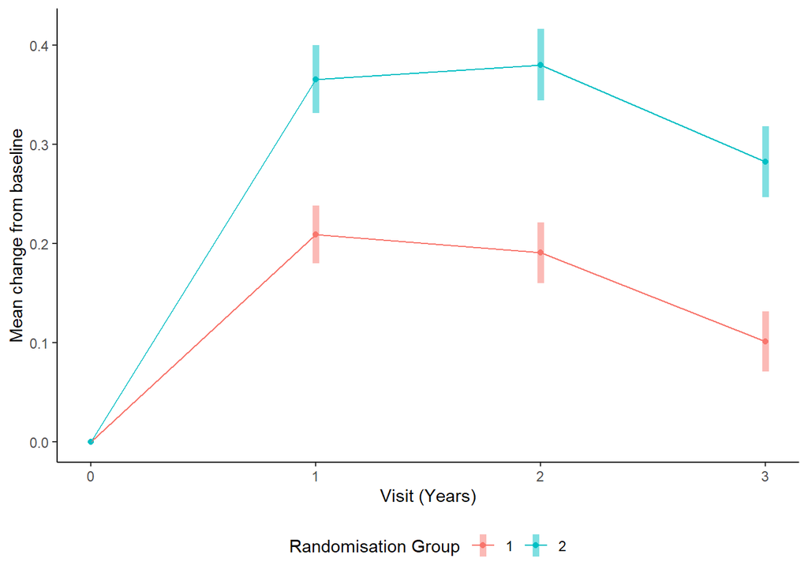

```r
# calculate all ems by time and group
group_time_ems <- emmeans(fitted_mods$unadj_mod,  ~ group_type_id + rc_trial_time)

# contrast to baseline by group
comp_to_baseline <- contrast(group_time_ems, rc_trial_time , "trt.vs.ctrl", by=  "group_type_id")

time_diff <- c(1:3)

to_bl_plot_df <- cbind(summary(comp_to_baseline)[,1:3],
                       confint(comp_to_baseline)[,6:7],
                       `Visit (Years)` = rep(c(1:3), 2))
# add baseline 0
to_bl_plot_df[7:8,] <- NA
to_bl_plot_df$group_type_id[7:8] = c(1,2)
to_bl_plot_df$estimate[7:8] = c(0,0)
to_bl_plot_df$`Visit (Years)`[7:8] = 0


to_bl_plot_df %>%
  ggplot(aes(`Visit (Years)`, estimate,color=factor(group_type_id), group=factor(group_type_id))) +
  geom_point() +
  geom_line()+
  geom_linerange(aes(ymin=asymp.LCL, ymax=asymp.UCL), size=2, alpha=.5) +
  theme_classic() +
  ylab("Mean change from baseline") +
  scale_color_discrete(name="Randomisation Group")  +
   theme(legend.position = "bottom")
```

```r
ggsave(file = paste0(params$response,"_",params$data,"_plot.png"), width = 12, height = 8, units = "cm")



to_bl_plot_df %>%
  transmute(group_type_id, `Visit (Years)`,
         estimate,
         LCL = asymp.LCL, UCL = asymp.UCL) %>%
  arrange(`Visit (Years)`,group_type_id) %>%
write.csv(file = paste0(params$response,"_",params$data,"_plotdata.csv"), row.names = FALSE)
```

## Result

Covariates included in adjusted models:

- `myb_age`: Age at Baseline
- `myb_gender`: Reported gender
- `cl_edu_yrs`: Years of education
- `rcal_modules_sum`: Number of modules person was eligible for
- `adri_baseline`: ADRI at Baseline

A linear mixed model with a random effect for patient and fixed effects of time point, randomisation group and their interaction was run. An additional analysis including covariates of myb_age, myb_gender, cl_edu_yrs, rcal_modules_sum, adri_baseline was run. We report estimates of the group difference in the change from baseline to three years follow up with 95% confidence interval, and associated Z statistic and p-value. The units of the effect size are standard deviations at baseline.

The unadjusted difference between randomisation groups of change from baseline to three year follow up was 0.181 ( 95%CI: 0.134- 0.228, Z=7.573, p<0.001) baseline standard deviations.

The difference between randomisation groups of change from baseline to three year follow up was 0.179 ( 95%CI: 0.132 - 0.226, Z=7.496,p<0.001) baseline standard deviations, adjusting for myb_age, myb_gender, cl_edu_yrs, rcal_modules_sum, adri_baseline.

Analysis by Nancy Briggs and Gordana Popovic on 2024-02-14